# 带有样本选择的 DID 和 CiC：模拟附件

Viviens (2026) 方法的一个最小可运行示例

连享会 (lianxh.cn)

2026-06-12

# 1 说明

这个 `.Rmd` 是推文的**附件**，不是完整推文。它的作用是复现推文第 7 节中的模拟：在真实 $ATT_{AO}=0$ 的数据生成过程中，朴素完全案例 CiC 可能稳定地估出正效应；修剪边界则会覆盖真实值，并且边界宽度随 AO 层占比下降而迅速扩大。

文档设置为 `html_notebook` 输出。点击 RStudio 的 `Knit` 后，代码、表格和图形都会显示在 HTML 中，效果接近 `.ipynb`。若要生成一个便于独立分享的 HTML 文件，可以在 RStudio 的 Knit 下拉菜单中选择 `Knit to HTML`，或把 YAML 中的输出切换为 `html_document`。

本版额外做了一点调整：图形不仅会嵌入 HTML，也会**显式保存到本地 `figures/` 文件夹**，便于随后上传图床。下面这段代码会显示当前工作目录，后续图片会保存在这个目录下的 `figures/` 中。

```r
getwd()
```

```
#> [1] "D:/JG/助教推文提交/2020助教推文/DID专题推文/B875-王昕冉：论文推介-带有样本选择的DID和CIC模型/ChatGPT-review"
```

```r
list.dirs(".", recursive = FALSE)
```

```
#> [1] "./figures" "./outputs"
```

# 2 1. 数据生成过程

模拟采用两期面板数据。$G_i=1$ 表示处理组，$S_{i1}$ 和 $S_{i2}$ 表示工资在两期是否可观测。这里使用负向单调性，即处理可能使一部分人退出受薪就业，因此排除 OT 层，仅保留 NO、OC 和 AO 三类主层。

真实的 AO 层处理效应设为 0。朴素估计出现偏差，不是因为能力混杂本身，而是因为完全案例样本中混入了 OC 层，使对照组第二期趋势被拖低。

```r
# 生成两期面板数据：
# - G 为处理组指示变量
# - V 为主层类型：NO、OC、AO
# - S1/S2 为工资是否可观测
# - Y1/Y2 为两期对数工资
#
# pOC 控制 OC 层比例；drop 控制 OC 层第二期结果相对 AO 层的下滑幅度。
gen_data <- function(N = 5000, pOC = 0.06, drop = 0.45) {
  G <- rbinom(N, 1, 0.5)                 # 处理组指示
  A <- rnorm(N, mean = 0.3 * G, sd = 1)  # 能力：影响工资，且与处理混杂
  W <- runif(N)                          # 工作依附度：决定主层，与 G 独立

  # 负向单调性：排除 OT 层，只保留 NO、OC、AO 三类。
  V <- ifelse(
    W < 0.06, "NO",
    ifelse(W < 0.06 + pOC, "OC", "AO")
  )

  # 第一期工资对 NO 层不可观测；第二期工资对 AO 层可观测，
  # OC 层只在对照状态下可观测。
  S1 <- as.integer(V != "NO")
  S2 <- ifelse(
    V == "AO", 1L,
    ifelse(V == "OC", as.integer(G == 0), 0L)
  )

  # AO 层满足 CiC：未处理潜在工资由同一个单调结构生成。
  e1 <- rnorm(N, 0, 0.30)
  e2 <- rnorm(N, 0, 0.30)

  Y1 <- 1.5 + A + e1
  Y2 <- 1.7 + 1.1 * A + e2              # AO 层真实处理效应为 0

  # OC 层不需要满足 AO 层结果模型。这里人为设置其第二期工资下滑，
  # 它会污染完全案例中的对照组趋势。
  oc <- V == "OC"
  Y2[oc] <- 1.7 + 1.1 * A[oc] - drop + e2[oc]

  Y1[S1 == 0] <- NA
  Y2[S2 == 0] <- NA

  data.frame(G, V, S1, S2, Y1, Y2)
}
```

# 3 2. 估计函数

下面实现三个量：

- 朴素完全案例 CiC 估计。
- 负向单调性下的 $\pi_0$ 插补。
- 负向单调性下的 $QTT_{AO}(q)$ 修剪边界。

```r
# 左连续经验分位数：
# Q(q) = inf{y: F(y) >= q}
# 对应 R 中 quantile(..., type = 1)。
Qhat <- function(x, q) {
  quantile(
    x,
    probs = pmin(pmax(q, 0), 1),
    type = 1,
    names = FALSE,
    na.rm = TRUE
  )
}

# 经验分布函数 F(y)。
Fhat <- function(x, y) {
  x <- x[!is.na(x)]
  ecdf(x)(y)
}

# 朴素完全案例 CiC。
# 它把两期都有工资的人直接当作可比样本。
cic_naive <- function(d) {
  cc <- d[d$S1 == 1 & d$S2 == 1, ]

  cf <- Qhat(
    x = cc$Y2[cc$G == 0],
    q = Fhat(cc$Y1[cc$G == 0], cc$Y1[cc$G == 1])
  )

  mean(cc$Y2[cc$G == 1], na.rm = TRUE) - mean(cf, na.rm = TRUE)
}

# Lemma 1 + Proposition 2：
# 负向单调性下 pi1 = 1，pi0 需要用选择方程插补。
pi0_hat <- function(d) {
  ES <- function(g, t) mean(d[d$G == g, paste0("S", t)])
  (ES(0, 1) / ES(0, 2)) * (ES(1, 2) / ES(1, 1))
}

# Proposition 1：
# 负向单调性下 pi1 = 1，只需要修剪对照组观测分布。
qtt_bounds <- function(d, qs, pi0) {
  obs <- d[d$S2 == 1, ]

  y1_t <- obs$Y1[obs$G == 1]
  y2_t <- obs$Y2[obs$G == 1]
  y1_c <- obs$Y1[obs$G == 0]
  y2_c <- obs$Y2[obs$G == 0]

  q_lb <- pmin(Fhat(y1_c, Qhat(y1_t, qs)) + (1 - pi0), 1)
  q_ub <- pmax(Fhat(y1_c, Qhat(y1_t, qs)) - (1 - pi0), 0)

  data.frame(
    q  = qs,
    LB = Qhat(y2_t, qs) - Qhat(y2_c, q_lb),
    UB = Qhat(y2_t, qs) - Qhat(y2_c, q_ub)
  )
}
```

# 4 3. 单次模拟：两个 AO 占比场景

这里设置两个场景：

- 场景 A：OC 层比例较低，AO 占比较高。
- 场景 B：OC 层比例较高，AO 占比较低。

`ATT_AO` 的边界用 $QTT_{AO}(q)$ 边界在分位数网格上的简单平均近似。

```r
run_one <- function(label, pOC) {
  d <- gen_data(N = SAMPLE_SIZE, pOC = pOC, drop = 0.45)

  pi0 <- pi0_hat(d)
  true_pi0 <- mean(d$V[d$G == 0 & d$S2 == 1] == "AO")
  naive <- cic_naive(d)

  qs_att  <- seq(0.05, 0.95, by = 0.005)
  qs_plot <- seq(0.05, 0.85, by = 0.005)

  b_att  <- qtt_bounds(d, qs_att,  pi0)
  b_plot <- qtt_bounds(d, qs_plot, pi0)

  att_lb <- mean(b_att$LB)
  att_ub <- mean(b_att$UB)

  list(
    label = label,
    data = d,
    bounds = b_plot,
    summary = data.frame(
      scenario = label,
      true_pi0 = true_pi0,
      pi0_hat = pi0,
      naive_cic = naive,
      att_lb = att_lb,
      att_ub = att_ub
    )
  )
}

set.seed(SEED)

case_A <- run_one(
  label = "场景 A：AO 占比较高",
  pOC = 0.06
)

case_B <- run_one(
  label = "场景 B：AO 占比较低",
  pOC = 0.24
)

single_run_results <- rbind(case_A$summary, case_B$summary)

# 保存结果表，便于后续检查。
write.csv(
  single_run_results,
  file = file.path(OUT_DIR, "single_run_results.csv"),
  row.names = FALSE
)

single_run_results
```

| scenario | true_pi0 | pi0_hat | naive_cic | att_lb | att_ub |
| --- | --- | --- | --- | --- | --- |
| 场景 A：AO 占比较高 | 0.928 | 0.954 | -0.00127 | -0.313 | 0.20 |
| 场景 B：AO 占比较低 | 0.755 | 0.742 | 0.09414 | -1.285 | 1.41 |

# 5 4. 绘图函数与本地保存函数

下面定义两个函数：

- `plot_bounds_inline()`：在 HTML 中直接显示图形；
- `save_bounds_png()`：把同一张图保存到本地 `figures/` 文件夹。

这样处理的好处是：推文附件中能看到运行结果，本地文件夹里也能拿到高清 PNG。

```r
plot_bounds_inline <- function(case) {
  b <- case$bounds
  s <- case$summary

  naive <- s$naive_cic
  pi0 <- s$pi0_hat
  title_main <- paste0(case$label, "：pi0_hat = ", round(pi0, 3))

  yr <- range(c(b$LB, b$UB, 0, naive), finite = TRUE)
  pad <- 0.08 * diff(yr)

  plot(
    b$q, b$LB,
    type = "n",
    xlim = range(b$q),
    ylim = c(yr[1] - pad, yr[2] + pad),
    xlab = "分位数 q",
    ylab = expression(QTT[AO](q)),
    main = title_main,
    family = "sans"
  )

  polygon(
    x = c(b$q, rev(b$q)),
    y = c(b$LB, rev(b$UB)),
    col = rgb(0.2, 0.45, 0.85, 0.22),
    border = NA
  )

  lines(b$q, b$LB, lwd = 2)
  lines(b$q, b$UB, lwd = 2)
  abline(h = 0, lwd = 1.5)
  abline(h = naive, lwd = 1.5, lty = 2)

  legend(
    "topright",
    legend = c(
      "QTT 边界",
      "下界",
      "上界",
      "真实效应 = 0",
      paste0("朴素 CiC = ", round(naive, 3))
    ),
    lwd = c(8, 2, 2, 1.5, 1.5),
    lty = c(1, 1, 1, 1, 2),
    bty = "n",
    cex = 0.90
  )
}

save_bounds_png <- function(case, filename, width = 1200, height = 720, res = 160) {
  dir.create(dirname(filename), showWarnings = FALSE, recursive = TRUE)

  png(
    filename = filename,
    width = width,
    height = height,
    res = res
  )

  plot_bounds_inline(case)
  dev.off()

  # 返回规范化后的本地路径，便于在 RStudio Console 或 HTML 输出中确认文件位置。
  normalizePath(filename, winslash = "/", mustWork = FALSE)
}
```

# 6 5. 图 1：AO 占比较高

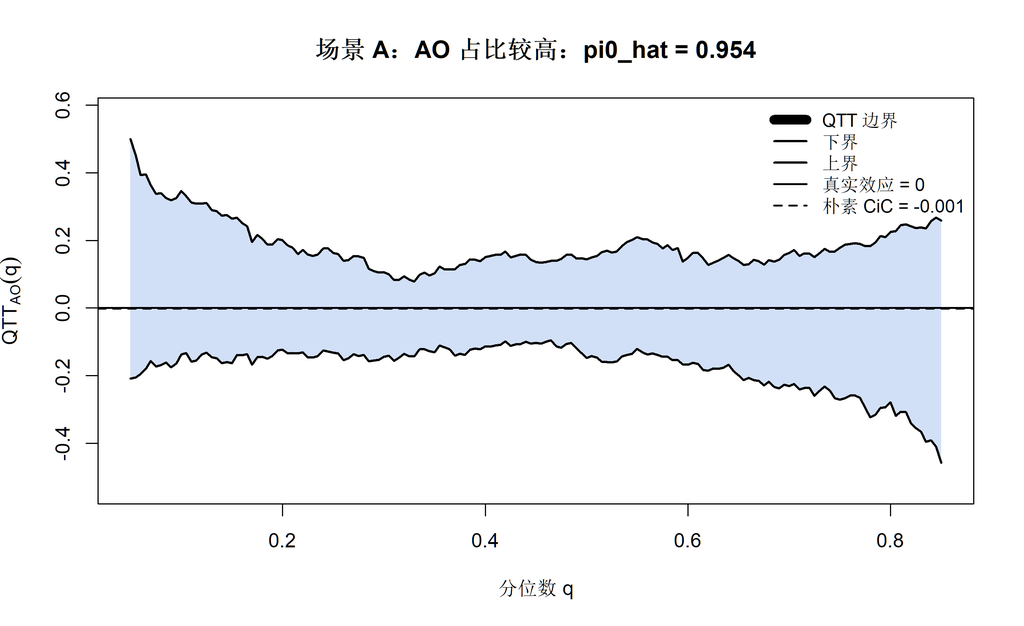

场景 A：AO 占比较高时的 QTT 边界

```r
plot_bounds_inline(case_A)
```

```r
fig_A_path <- save_bounds_png(
  case_A,
  file.path(FIG_DIR, "fig_viviens_cic_bounds_scenario_a.png")
)

fig_A_path
```

```
#> [1] "D:/JG/助教推文提交/2020助教推文/DID专题推文/B875-王昕冉：论文推介-带有样本选择的DID和CIC模型/ChatGPT-review/figures/fig_viviens_cic_bounds_scenario_a.png"
```

# 7 6. 图 2：AO 占比较低

这张图对应场景 B。此时 $\hat\pi_0$ 约为 0.75，边界明显变宽，尾部几乎失去信息量。这不是估计程序出错，而是样本选择更严重时，数据本身无法支持更窄的识别结论。

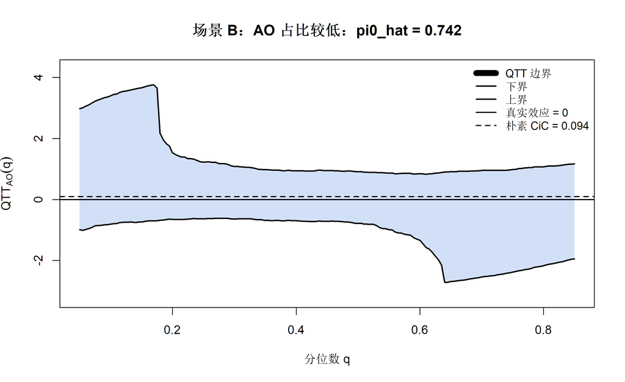

场景 B：AO 占比较低时的 QTT 边界

```r
plot_bounds_inline(case_B)
```

```r
fig_B_path <- save_bounds_png(
  case_B,
  file.path(FIG_DIR, "fig_viviens_cic_bounds_scenario_b.png")
)

fig_B_path
```

```
#> [1] "D:/JG/助教推文提交/2020助教推文/DID专题推文/B875-王昕冉：论文推介-带有样本选择的DID和CIC模型/ChatGPT-review/figures/fig_viviens_cic_bounds_scenario_b.png"
```

# 8 7. 本地输出文件检查

运行到这里后，本地 `figures/` 文件夹中应当已经有两张 PNG 图片。下面列出图片路径，便于直接定位和上传图床。

```r
list.files(FIG_DIR, pattern = "\\.png$", full.names = TRUE)
```

```
#> [1] "figures/fig_viviens_cic_bounds_scenario_a.png"
#> [2] "figures/fig_viviens_cic_bounds_scenario_b.png"
#> [3] "figures/figure-scenario-a-1.png"
#> [4] "figures/figure-scenario-b-1.png"
```

# 9 8. 蒙特卡洛检查

```r
mc_one <- function(pOC = 0.06) {
  d <- gen_data(N = SAMPLE_SIZE, pOC = pOC, drop = 0.45)
  pi0 <- pi0_hat(d)

  qs_att <- seq(0.05, 0.95, by = 0.005)
  b <- qtt_bounds(d, qs_att, pi0)

  c(
    pi0_hat = pi0,
    naive_cic = cic_naive(d),
    att_lb = mean(b$LB),
    att_ub = mean(b$UB),
    cover_zero = as.numeric(mean(b$LB) <= 0 & mean(b$UB) >= 0)
  )
}
```

```r
if (RUN_MC) {
  set.seed(SEED + 1)

  mc_mat <- replicate(MC_REPS, mc_one(pOC = 0.06))
  mc_df <- as.data.frame(t(mc_mat))

  mc_summary <- data.frame(
    statistic = c(
      "pi0_hat_mean",
      "naive_cic_mean",
      "naive_cic_sd",
      "att_lb_mean",
      "att_ub_mean",
      "coverage_zero"
    ),
    value = c(
      mean(mc_df$pi0_hat),
      mean(mc_df$naive_cic),
      sd(mc_df$naive_cic),
      mean(mc_df$att_lb),
      mean(mc_df$att_ub),
      mean(mc_df$cover_zero)
    )
  )

  write.csv(
    mc_df,
    file = file.path(OUT_DIR, "monte_carlo_raw_results.csv"),
    row.names = FALSE
  )

  write.csv(
    mc_summary,
    file = file.path(OUT_DIR, "monte_carlo_summary.csv"),
    row.names = FALSE
  )

  mc_summary
} else {
  cat("RUN_MC = FALSE，已跳过蒙特卡洛模拟。")
}
```

| statistic | value |
| --- | --- |
| pi0_hat_mean | 0.9360 |
| naive_cic_mean | 0.0313 |
| naive_cic_sd | 0.0123 |
| att_lb_mean | -0.3814 |
| att_ub_mean | 0.3019 |
| coverage_zero | 1.0000 |

# 10 9. 结果解读

从单次模拟和蒙特卡洛结果可以看到三个结论。

一是 $\pi_0$ 的插补结果与真实 AO 占比较接近。这里的关键是主层由工作依附度 `W` 决定，而 `W` 与组别 `G` 独立；若让主层直接由能力 `A` 决定，由于 `A` 与处理组身份相关，选择方程中的独立性条件会被破坏。

二是朴素完全案例 CiC 会产生稳定的正偏。它把两期都有工资的人直接拿来比较，看似避开了缺失问题，实际上改变了比较对象。OC 层污染了对照组第二期趋势，使反事实工资被低估，从而把真实为零的效应估成正值。

三是修剪边界的宽度主要由 AO 层占比决定。场景 A 中 AO 占比较高，边界仍有一定信息量；场景 B 中 AO 占比较低，边界迅速变宽。这个结果不应被理解为方法“效率低”，而应理解为部分识别方法对数据可支持结论的诚实表达。

# 11 10. 会话信息